# The Role of MPAs in Bycatch Reduction

Daniel Ovando

Darcy Bradley

Echelle Burns

Lennon Thomas

2021-06-09

bycatch paradox - mpas good in some ways, bad in others

Thinking through the “naive” MPA design strategies to compare against the optimized outcomes. Thoughts at the moment below. These can be run in a few seconds each, so we cab be be pretty liberal in coming up with combinations if there are other ideas people want to try, but also if some of these seem pointless can drop as well! 6:11 Design strategies 1. Assign protection by SSB / SSB0 weighted abundance in space (protect the highest concentrations of the most threatened species) 2. Assign protection by bycatch rates (distribution of biomass bycatch / biomass target) 3. Assign protection by targeting fishing effort 4. Assign protection by avoiding fishing effort Knowledge states 1. Degrees of accuracy over the thing being measured (i.e. error in the design strategy) 2. Number of species considered (e.g. design aronnd only 2 bycatch species instead of all) 3. über naive: just close off random patches up to a specified size We then plot these points in objective function space and compare to the efficiency frontier / consider frequency and magnitude of conservation and economic tradeoofs The question all this is answering: how sensitive are conservation and economic outcomes to design strategy / uncertainty when there are technical interactions and heterogeneity in habitat? The first stage is teeing up the idea that beyond conservation / yield tradeoffs, as you increase habitat heterogeneity with technical interactions you increase the potential for conservation tradeoffs. But, the degree is going to be super context dependent, so to dive in a bit we then focus on this case study of the particular species / habitat overlap in the WCPO. Further work might reveal more generalities in this, but htis is basically getting a sense for the potential magnitude of the challenge.

# 1 Introduction

Marine protected areas (MPAs) are a growing part of the marine conservation toolbox, with 7.4% of the world’s oceans currently protected and, and bodies such as the IUCN calling for 30% protection by 2030. Many of the largest of these MPAs are being implemented in the form of “blue-water” MPAs largely covering pelagic ecosystems, characterized by highly mobile species and fishing fleets using a diverse mix of static and dynamic ocean features. These systems operate very differently from the coastal areas where modern MPA design practices have been developed. Pelagic systems are also characterized by combinations of relatively abundant species targeted by fishing, such as most tuna stocks, and highly threatened species caught as incidental “bycatch” in targeted fishing operations, such as oceanic whitetip sharks. Blue-water MPAs are increasingly being proposed specifically to benefit these by-catch populations while minimizing losses or where possible providing benefits to fisheries.

The core models underpinning MPA science have largely been based on stylized versions of near-shore reef-style xx what to call that, like coral / rocky / kelp forest, etc xx systems, where multiple species often share common habitat, and adults have reasonable site fidelity while larvae are broadly dispersed. Pelagic ecosystems have vastly different dynamics than coastal seas (Game et al. 2009; Lubchenco et al. 2003), characterized by highly migratory species specialized to take advantage of highly dynamic ocean features such as eddies currents while also utilizing static features such as seamounts. Pelagic ecosystems also support both coastal domestic fishing industries along with highly mobile international high-seas fishing operations. Given these dynamics, it remains unclear how many of the lessons from coastal MPA science are applicable to pelagic ecosystems [@ovando2021XX].

However, the dynamic nature of pelagic systems also creates a risk of unintended conservation consequences of MPAs. When an MPA is implemented on former fishing grounds, fishing fleets have two choices: exit the fishery or move to new fishing grounds. When MPAs redistribute effort away from one area and into another, they can accidentally increase fishing effort on species found within the new fishing grounds (Abbott and Haynie 2012). This problem of policy “leakage” is well known in many environmental fields (**citations?**) but the general properties of this problem have received relatively little attention in the theoretical or empirical MPA literature [see Abbott and Haynie (2012);(**savina2008?**);fulton2011a;@baum2003 for notable exceptions]. We fill this gap by

- Assessing the conditions under which this may be a problem using a generalized simulation environment
  - General insights about design strategy, effect of varying degrees of habitat overlap, etc, tradeoffs with fisheries
- Given that “it depends” nature of the problem, assess the specific potential for this problem in a case study
  - specific insights about design strategy, effect of varying degrees of habitat overlap, etc, tradeoffs with fisheries

Our goal here is not to provide tactical recommendations on the design of blue-water MPAs, but rather to provide a strategic evaluation of the sensitivity of bycatch populations and targeted fisheries to key unknowns and design choices in MPA planning.

# 2 Methods

Hastings, Gaines, and Costello (2017) employed a simply model to derive conditions under which MPAs would benefit bycatch species. However they also pointed out that even small increases in model complexity quickly make analytical solutions to the effects of MPAs intractable. As such, we based our numerical analysis on a spatially explicit, multi-species, multi-fleet, bio-economic model we call [`marlin`](https://github.com/DanOvando/marlin). Models of MPAs span a wide range of complexity, from simple analytical tools to end-to-end ecosystem models (Fulton et al. 2015). `marlin` follows a “models of intermediate complexity” (MICE) philosophy (Plagányi et al. 2014) targeted specifically around the role of technical interactions across species. Many MPA models simulate the impacts of MPAs on a single-species level (**ovando2021XX?**). This can be useful for for example examining the ways in which species-specific life history traits interact with fleet dynamics to influence MPA outcomes. However, bycatch problems are driven by technical interactions, in which fishing effort for a target species incidentally captures another species xx how do we want to talk about this in here? Like usually incidentally, but clearly sometimes people try and catch sharks too xx. `marlin` accounts for this by allowing the user to simulate an arbitrary number of fleets capable of catching an arbitrary number of species in a spatial area. Different fleets can place different economic value on different species, while also having species-specific selectivity functions. This allows us to simulate bycatch dynamics of MPAs in pelagic ecosystems.

We first ran a series of simulation exeriments designed to explore broad sensitivities of bycatch and fisheries to key factors.

## 2.1 `marlin`

Lots of equations. Pretty standard age-structured population models, extra bells and whistles that need explaining

- Design of movement and habitat
  - Movement is a product of distance and habitat, such that critters will all else equal move to the closest patches with the best habitat
- Ontogenetic shifts
- Nature of fleet tuning (shared effort different q per species)

## 2.3 Species & Fleets

Each simulation includes a longline and a purse-seine fleet. Each species can have a separate price (USD/kg) and selectivity ogive for each fleet, as dictated by the literature.

Fleets exert a given amount of effort in a patch each time step. The catch resulting from that effort is given by the Baranov (**baranov18XX?**) equatino

$$C_{f,s,p,t} = \frac{q_{f,s}E_{f,p,t}}{q_{f,s}E_{f,p,t} + m_s} \times \sum_{a=0}^{A}B_{s,p,t,a} \times (1 - e^{-(q_{f,s}E_{f,p,t}S_a + m_s)})$$

Where $C$ is catch by fleet $f$ of species $s$ in patch $p$ in timestep *t*. $E$ is total effort by that fleet in a patch and time step, $m$ is natrual mortality for a given species, $B$ is biomass at age *a*, and $S$ is selectivity.

$q$ is the catchability coefficient for fleet $f$ and species $s$.

Fleets distribute themselves in space according to revenue per unit effort

$$R_{f,p,t} = \frac{\sum_{s=1}^{S}v_{f,s}C_{f,s,p,t}}{E_{f,p,t}}$$
Where $v$ is the price per kg of each species. Bycatch in the model is defined through the price. An unregulated species with no commercial value would have $v = 0$, whereas a regulated and prohibited species might actually have a negative price.

Effort per fleet is set a a constant of 1 per patch, and the model then tunes $q_{f,s}$ such that given all the other parameters of the model the fishing mortality rate for each species matches the best available level for that species. This is what allows the model to capture bycatch dynamics: A fleet can distribute itself purely based on revenues from target species, but through the $q$ parameter still exert fishing mortality on other species, even if that species has a price of zero, if those bycatch species inhabit the same patches as the more valuable target species.

### 2.3.1 Species Overlap

We simulate degrees of species overlap using two parameters, $\sigma_c$ and $\sigma_h$. All species start with the assumption that the centroid of their preferred habitat occurs in the center-most patch of teh two dimensional system simulated by marlin. For our simulations, we then generated a random deviation from that default centroid for each species using $\sigma_c$ in the manner

$$centroid_s \sim normal(center,\sigma_c)$$
where *s* denotes species, and *center* is the coordinate of the central cell. In this way, the larger $\sigma_c$ grows, the more variation there is betwen the centroid of the preferred habitat for each species.

We then control the spread of a creatures preferred habitat around that centroid per a Gaussian dispersal kernal in the manner

$$habitat_{p,s} = \frac{1}{\sqrt{2\pi\sigma_h^2}}e^{-\frac{d_p^2}{2\sigma_h^2}}$$

Where $d$ is the euclidian distance from the $centroid_s$ to patch $p$ and $\sigma_h$ controls the dispersal of the habitat around that range.

### 2.3.2 Ontogenetic Shifts

`marlin` allows for different habitats to be used by adults vs. recruits. For scenarios with ontogenetic shifts ,we assign recruits to a habitat grid that is the inverse of $habitat_{p,s}$. In this way organisms enter the model living on one area, and then transition to adult habitat at older life stages.

XX this isn’t very interesting at this point since movement is so high so I vote we get rid of it for now XX.

### 2.3.3 Seasonal Migration

For this paper `marlin` is set to run with two seasons per year. When seasonal movement is turned on, animals use one habitat matrix in season one, and the inverse of that habitat matrix in season 2.

### 2.3.4 MPA Design Strategies

MPA design is governed by four general parameters: the number of cells to place inside an MPAs, and the design strategy used to place the MPAs, the species considered in the MPA planning process, and the accuracy of the information used in the planning process.

We consider 5 different MPA placement strategies.

For the “depletion” strategy, MPA locations are prioritized based in proportion to the spawning stock biomass (SSB) of the most depleted species. So, patches with high amounts of highly depleted species are prioritized over patches with high biomass of lightly depleted species.

For the “rate” strategy, MPAs are placed in based on the depletion-weighted catch relative to the total catch in a patch. So, patches where with high rates of catch of depleted species relative to totcal catch are prioritized.

For the “avoid_fishing” strategy, MPAs locations are prioritized inversely to fishery catches. So, patches with low catches are prioritized over patches with high catches.

For the “target_fishing” strategy, MPAs locations are prioritized proportionally to fishery catches. So, patches with high total catches are prioritized over patches with high catches.

For the “area” strategy, we simply assign patches in sequential order until the desired total MPA size is reached.

The information used to inform each MPA design strategy (except area) can include a multiplicative observation error term $\sigma_{obs}$ where

$$information \sim lnorm(data,\sigma_{obs})$$

For example, for the depletion scenario, $\sigma_{obs}$ controls the accuracy of the spatial depletion data used to prioritize MPA placement.

## 2.4 Case Study

In order to constrain the parameter space somewhat, we also ran a series of case study experiments. Rathere than interating over different habitat configurations and movement dynamics, we fix habitat for each species based on the results of (**bradley2021XX?**), and set ontogenetic movement and seasonal migrations to FALSE.

### 2.4.1 MPA Network Optimization

$$obj = \alpha \times scale(\sum_{s=1}^{S}\frac{ssb_s}{ssb0_s}) + (1 - \alpha) \times scale(\sum_{s=1}^{S}R_s)$$

where $\alpha$ controls the relative weight assigned to a “conservation” objective based on depletion, relative to an “economic” objective based on revenues. The ‘scale’ function rescales both objective components to the range of 0 to 1 to facilitate interpretation of $\alpha$ xx come up with a better version of this XX

The optimization routine itself works through a sampling-importance-resampling algorithm. In the first iteration of the algorithm, the marginal contribution of each individual patch to the objective function is calculated. The patch with the highest objective function value is then placed in an MPA. For the remaining iterations, we sample *X* cells from the remaining non-MPA cells with probability proportional to their marginal value to the objective function in the last iteration. We then calculate the marginal value of each of these cells when individually added to the MPA network begun in the prior step. The cell with the higheset marginal value is then added to the MPA network, and the marginal values of the non-selected but sampled cells are updated based on the values in that iteration. The process then continues until the desired MPA size is reached.

## 2.5 Assessing Performance

Each model run started at equilibrium conditions and was then run for 40 years (80 seasons. We assessed performance by comparing relevant metrics (e.g. depletion and revenue) under a given scenario with MPAs relative to the values of those same metrics in the simulated counterfactual world identical in every way save for the presencee of MPAs.

# 3 Results

## 3.1 Experiments: How severe and undere what conditions are unintended conservation consequences? (clearer name for these)

Make clear that a goal of all this complexity was to see if there were any clear emergent properties (this thing matters way more than this thing). We highlight some of those, but given the complexity we found we present the complexity of interacting ways in which different things can effect the conservation outcomes of MPAs

XX after looking through these should widdle it down to only things you actually examine, annoying / no point to having a bunch of unexplained minor variation in the mix relatede to things like ontogenetic shifts)

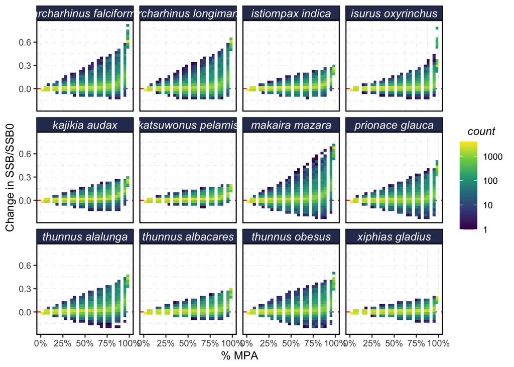

(#fig:exp_results)Results of simulation experiments on change in SSB/SSB0 (y-axis) as a function of MPA size (x-axis). Color indicates number of simulations in log-10 space that fell into a particular effect size at a given MPA size

Moving to expressing things are percentage of species with some / significant loss

key result: Assuming perfect information, degree of habitat matters buts its messy. Both the depletion and target_fishing strategies are capable of completely avoiding losses if all species share the same habitat. As habitat non-overlap (xx better phrase) inceases, this gets harder to do, and both incur some losses. All of the other placement strategies exhhibit some losses, even with perfect overlap, at some MPA size.

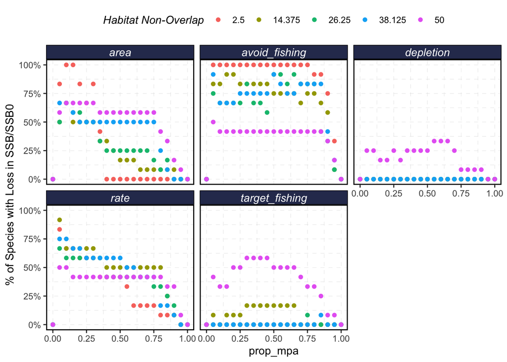

(#fig:hab_effect)Precent of species with some degree of loss in SSB as a function of MPA size, MPA design strategy, and degree of habitat non-overlap (sigma_c), come up with a better name for this. Perfect information, no seasonal movement, all species considered in planning.

moving away from perfect information though, things get messier: now just looking at the same plot but with all the other options turned on things get messy quickly.

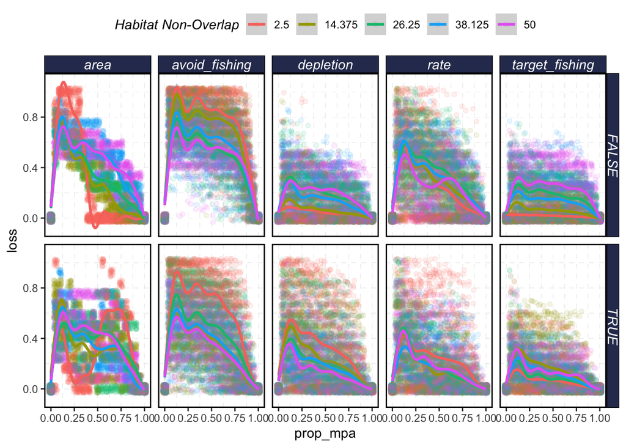

(#fig:mess_effect)Precent of species with some degree of loss in SSB as a function of MPA size, MPA design strategy, and degree of habitat non-overlap (sigma_c), come up with a better name for this. Rows indicate presence or absence of seasonal movement.

same thing but now for SSB loss greater than or equal to 10%

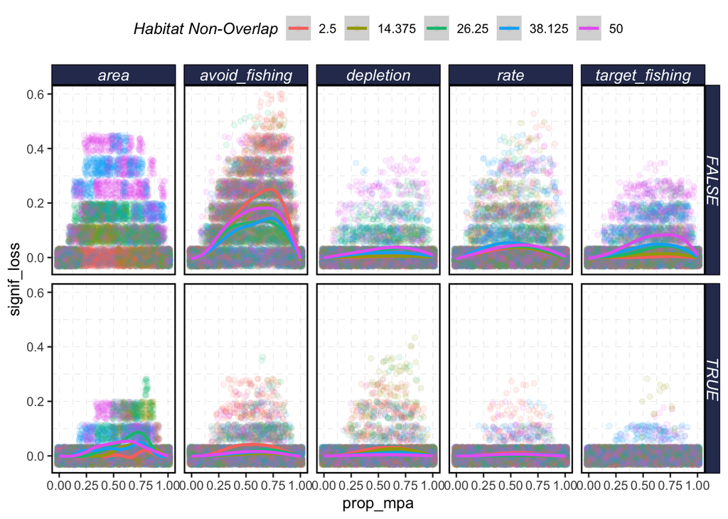

xx the problem here. These things all interact in so many complex ways that it’s hard to look at either graphically or statistically, and maybe for the best. i.e. the answer isn’t “if habitat overlap is less than XX% you might have a problem, otherwise you’re fine,” but rather that a bunch of things can interact to cause potential problems. but that’s hard to explain xx.

- Relationship of degree of overlap and probability of some loss happening
  - compare to Maite’s paper
- Other key sensitivities, e.g. missing species, quality of information
- General performance across design strategies: are some uniformly better than others
- Influence on fishing/conservation tradeoffs
- Case study
  - degree of risk from leakage
  - tradeoffs between avoiding leakage and fisheries outcomes
  - Value of optimization

# 4 Discussion

XX stress a key difference: may other papers on this are static, in that they just some up displacement on different layers, rather than addressing dynamic respones over tim xx

We show…. - sensitivity of both conservation and fishery outcomes to pelagic realism and design choices - compared to targeted / dynamic intervention… - value of information would be great…

**what is novel????**

Contrast to coastal MPA theoretical work - Hastings, Gaines, and Costello (2017) - (**ovando2021?**) - (**white2010?**) - not quite sure what to do about points raised in (**fulton2011a?**) - to what extent has this been done…

The paragraph from (**fulton2011a?**) that broke me…

" Spatial management was insufficient as the dominant management lever because it proves quite difficult to strike the balance between protecting areas that are of a size sufficient to produce any conservation benefit and providing sufficient fishing grounds to sustain an econom- ically viable industry (which is not possible in many fisheries if closures on the order of 70–80% or more are imposed, Fulton et al. 2007). More- over, Savina etal. (2008) found that effort displaced by closures potentially undermines any benefits coming from the zoning. For instance, strong improvements in diversity (by nearly 20%) under heavy fishing pressure occurred if effort outside a marine protected area (MPA) was controlled. However, without effort control, there was a significant (>20%) drop in overall diversity. Fulton et al. (2007), Savina et al. (2008), Smith et al. (2010) and unpublished work associated with Horne et al. (2010) all found that while spatial management appears to be an effective means of satisfying conservation objectives con- cerning habitat and restoring age-structures of less mobile species, benefits from closures for individual species depend on its trophic position, degree of mobility, geographical distribution and extent of ontogenetic shifts in habitat use and depth (highly mobile or prey species do not benefit in the way that more site attached or predatory species do)."

Lots of studies have shown that lots of things matter, can we provide guidance on which things are priorities?

Where does this fit in context of (**smith2021?**)? One important difference is that they point out differences in effectiveness, where effectiveness is still almost always positive, since they just measure leatherbacks. So theri fig 5, there are a few cases where leatherback catches actually go up, but it’s rare. So, extending to multiple species and keeping track off all of them shows it’s even harder

How does this contrast with the the large and growing dynamic ocean management lit? - By definition, with perfect information dynamic $\geq$ static spatial controls - DOM literature is mostly static, tracks displacemento onto static abundance / risk layers - Doesn’t allow for dynamic impacts, for example fleet adjustments based on updated economic surface, or short-term costs for long-term benefits (can overstate costs?) - Dynamic model allows for delta between dynamic policies, e.g. Fmsy vs DOM - analytical models a la hastings have value but do / don’t stand up to realism

Presentation of the model as a MICE model for MSP - reasonable parameterizable - flexible - fast

Focus of debate has been on fisheries and yields. As MPAs move to pelagic systems though, we show that conservation outcomes also depend on correctly identifying ecological state / design decisions etc.

# 5 References

Abbott, Joshua K., and Alan C. Haynie. 2012. “What Are We Protecting? Fisher Behavior and the Unintended Consequences of Spatial Closures as a Fishery Management Tool.” *Ecological Applications* 22 (3): 762–77. https://doi.org/https://doi.org/10.1890/11-1319.1.

Fulton, Elizabeth A., Nicholas J. Bax, Rodrigo H. Bustamante, Jeffrey M. Dambacher, Catherine Dichmont, Piers K. Dunstan, Keith R. Hayes, et al. 2015. “Modelling Marine Protected Areas: Insights and Hurdles.” *Phil. Trans. R. Soc. B* 370 (1681): 20140278. https://doi.org/10.1098/rstb.2014.0278.

Game, Edward T., Hedley S. Grantham, Alistair J. Hobday, Robert L. Pressey, Amanda T. Lombard, Lynnath E. Beckley, Kristina Gjerde, Rodrigo Bustamante, Hugh P. Possingham, and Anthony J. Richardson. 2009. “Pelagic Protected Areas: The Missing Dimension in Ocean Conservation.” *Trends in Ecology & Evolution* 24 (7): 360–69. https://doi.org/10.1016/j.tree.2009.01.011.

Hastings, Alan, Steven D. Gaines, and Christopher Costello. 2017. “Marine Reserves Solve an Important Bycatch Problem in Fisheries.” *Proceedings of the National Academy of Sciences*, August, 201705169. https://doi.org/10.1073/pnas.1705169114.

Lubchenco, Jane, Stephen R. Palumbi, Steven D. Gaines, and Sandy Andelman. 2003. “Plugging a Hole in the Ocean: The Emerging Science of Marine Reserves1.” *Ecological Applications* 13 (sp1): 3–7. https://doi.org/10.1890/1051-0761(2003)013[0003:PAHITO]2.0.CO;2.

Plagányi, Éva E, André E Punt, Richard Hillary, Elisabetta B Morello, Olivier Thébaud, Trevor Hutton, Richard D Pillans, et al. 2014. “Multispecies Fisheries Management and Conservation: Tactical Applications Using Models of Intermediate Complexity.” *Fish and Fisheries* 15 (1): 122. https://doi.org/10.1111/j.1467-2979.2012.00488.x.

## 5.1 Figure Ideas

Are there or are there not tradeoffs in conservation and fisheries yields

Interesting considerations we do biodiversity MPAs we define biodiversity as system diversity and we put all the species in there, threatened bycatch species become the the focus and stated objective is ramp up the value of bycatch species . There might be instances where just the biodiversity base actually gets you a better outcome than . There might be overlap and not.

Dig into that mismatch

We can explore that mismatch between is the issue q and is the issue of spatial habitat

### 5.1.1 Fig.1 Motivating figure - basically something like the shortfin mako example

### 5.1.2 Fig.2 Case study figure for WCPO: shows degree of overlap in species abundance in space and time, as well as a platform for some examples of MPA networks designed around different paradigms

### 5.1.3 Fig.3 Tradeoff plots across species, though will need to put some thought into visualizing across species. But something to convey the idea of whether there are tradeoffs among species in the case study of the WCPO high seas style system. Interestingly, you know that if you closed 100% all benefit, so doing this along a gradient is interesting, are there tradeoffs at low sizes that disappear with higher? Actually you might expect a dome-shaped tradeoff, where there are no tradeoffs at low size since little displacement, largest tradeoffs in the middle where you maximize displacement but still haven’t maximized protection, and then no tradeoffs at the extreme where everything is protected. If you have a small enough number of species, say less than 10, then can do color / shape by species, mpa size on x axis, change in biomass on y axis, and connected lines for design paradigms. If not too busy, would be good to have a counterfactual where everything is the same except species are all homogeneously distributed

### 5.1.4 Fig 4. Similar idea but, now bringing fishing in there. Maybe collapsing down a few axes, so you do like percent increase in total bycatch by total fishing, or some measure of collective benefit / loss, as a function of MPA size. Maybe highlight inflection points that seem to minimize fishery losses while also minimizing tradeoffs with bycatch

### 5.1.5 Fig 5 + Figures showing a few select “what if the world were different,” i.e. how important is movement rate, DD form, etc.

# 6 Scraps

Need to do an optimization here, calculate the marginal value of added cells.

What’s this about? Pointing out a problem, which to make impactful would require making the case that there is a problem with current design strategies. e.g.. “MPAs are often designed like this (simple dispersive models with constant habitat, or MARXSAN style things), and doing that does/does not create problems A tactical evaluation. Picking a handful of high profile MPAs, parameterizing all the knowns as well as possible, iterating over unknowns, and see what the range of outcomes are. Cleaner, more impactful, but also opens it up (depending on the results) to a details fight about very specific modeling choices How plausible are losses? Maybe we drill down on this a bit. From a purely bycatch perspective, the usual questions of fisheries tradeoffs aren’t on the table (but can add to the discussion considerations of how much target fishing you give up). Given that then, while it’s possible that”targeted" interventions would work better (ignoring costs/enforcement, etc), there’s really no reason not to do MPAs. Unless, you actually end up concentrating fishing pressure outside on populations. So, we consider how plausible is it for that to really happen. Issue here is that seems likely to be pretty hand-wavey. Most likely that the vast majority of simulations will show positive impacts, but have no way of assigning probabilities to any one state of nature.

The Role of Blue-Water Marine Protected Areas in Bycatch Reduction

What’s the question: How effective are Blue-Water MPAs in reducing fishing mortality of important pelagic bycatch species?

Another angle. There’s going to be a lot of unknowns in designing BWMPA. How much does not fully understanding a few key life history (e.g. movement) matter, and how much does the role that the species plays in the broader fleets portfolio matter

Could simulate habitat from a multivariate normal, where you use the sigma to control how similar rasters are across species

Bycatch is a significant driver of population declines for many pelagic species Sharks, seabirds, mammals, etc MPAs increasingly turned to as a solution for conservation problems, etc. MPA science is largely based on dynamics of coastal systems. Open-ocean ecosystems have very different dynamics that require dedicated research Burgess et al. (2018) estimated the reductions in fishing mortality needed to halt declines for a number of bycatch species Here we ask, what are the key drivers of bycatch conservation outcomes from MPAs? There are all of these species; you reduce fishing mortality. You can either do fisheries management, or you can do MPAs, let’s focus in on the MPA side. This could reduce fishing mortality, or it could do, and it depends on the dynamics of the species and the fleets. When can MPAs reduce fishing mortality enough for bycatch species? And where can you go wrong?

It doesn’t make any sense to ask “do MPAs help bycatch”: the question is obviously it depends. To quickly make this case, we’ll assume that a species is in need of recovery. We then do the simple mako example to show that effects of spatial closure depend on the overlap of habitat and the assumption of fleet dynamics, and provide some empirical evidence that in particular effort redistribution is not unlikely.

Determining the effect of an MPA network on bycatch then will also depend on trying to get close to a tactical model. But, this creates a problem for blue water systems in particular. Can make the argument that given the centrality of relatively static habitat features in coastal MPAs “protect the key habitats” might not be a bad strategy from a conservation strategy. But in highly mobile pelagic systems there (may be) a lot more variables in play. Where should researchers direct their attention?

To reduce the parameter space, we constrain ourselves to a system where 1) we know the species involved 2) we have some sense of the relative depletion and value of the different species and 3) some basic life history of the species. We then vary commonly unknown parameters, particularly preferred habitats, spatial catchability, movement rates etc, and pair these simulations with different MPA designs, and examine the conservation outcomes for bycatch species.

What i don’t like about this

There isn’t an “answer” to this: baring something like “changing the type of density dependence never had any effect greater than XX%,” for anything that on occasion has an impact the answer of “how much” will almost always depend on what else is going on.

So, it seems like there are two real angles of attack here

Pointing out a problem, which to make impactful would require making the case that there is a problem with current design strategies. I.e. "MPAs are often designed like this (simple dispersive models with constant habitat, or MARXSAN style things), and doing that does/does not create problems A tactical evaluation. Picking a handful of high profile MPAs, parameterizing all the knownns as well as possible, iterating over unknowns, and see what the range of outcomes are. Cleaner, more impactful, but also opens it up (depending on the results) to a details fight about very specific modeling choices

Methods

Collect life history for key bycatch species and target species, cite Bradley et al. pulling together species distribution and threats etc. Introduce marlin Parameterize marlin runs with “knowns” from life history of bycatch and target species Highlight key “unknowns” that we will iterate over, e.g. fleet models, density dependent movement, timing of density dependence etc Simulate effects of MPAs given reasonably realistic situations but iterating over key unknowns Evaluate the range of outcomes and key drivers of MPA effects I’m thinking we try and avoid a really specific case study but hard not to accidentally do one without making everything up….

Results Range of likely changes in fishing-induced mortality for the species selected Key drivers of uncertainty in those outcomes, focusing on things that switch states from reduction to increase in mortality How common are conservation tradeoffs between bycatch species? Fishery impacts

Discussion What does this say about BWMPAs and bycatch? Not going to get into design decisions here, depending how common tradeoffs are I think that will be the main focus Highlight any species that frequently induced tradeoffs Tee up future research MPAs in context of other management MPAs as risk reduction strategy Etc.